# Env. 710 HW 8

More Anova Models

Talia Neal

10.25.18

Problems Analyze the data for the two examples below. Make sure to use the appropriate ANOVA design for each study. For each problem, write a 1-page description of your analysis and the results. Please include your code at the bottom of your write-up in R Markdown. Each write-up should include the following information:

## Problem 1

Evaluate the effect of salt on plant biomass growth in 24 experimental vegetation plots (download salt.csv). The assigned treatment (one of 6 levels of salt addition: 10, 15, 20, 25, 30, 35 g m-2) is applied to the soil of a plot and at the end of the experiment the biomass of plants in each plot is measured. The experimental units are grouped into four blocks of six plots each, based on geographic proximity, and the treatments are assigned completely at random within each block. Thus, each treatment occurs exactly once in each block.

Based on a visual examination of the experiment results, it does appear that there are differences among the treatment levels. In addition, there does appear to be an effect from blocking as well; biomass in block 4 appears substantially lower accorss the the board, including negative values for the 30g treatment.

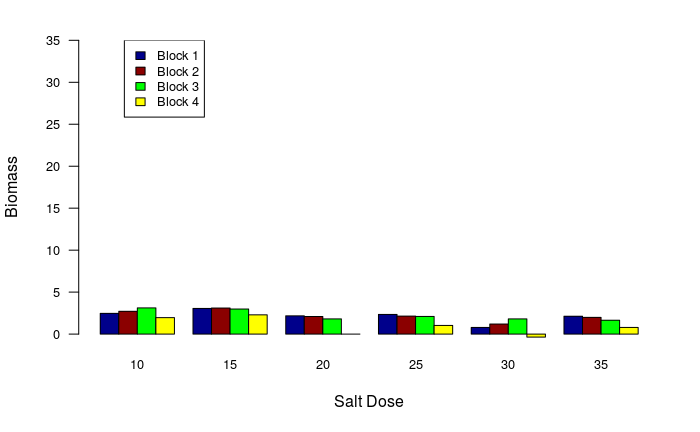

```
Analysis of Variance Table

Response: biomass
              Df  Sum Sq Mean Sq F value    Pr(>F)
factor(salt)   5 10.6517 2.13034  17.233 9.565e-06 ***
factor(block)  3  7.0682 2.35607  19.058 2.236e-05 ***
Residuals     15  1.8544 0.12362
---
Signif. codes:  0 ‘***’ 0.001 ‘**’ 0.01 ‘*’ 0.05 ‘.’ 0.1 ‘ ’ 1
[1] 4
```

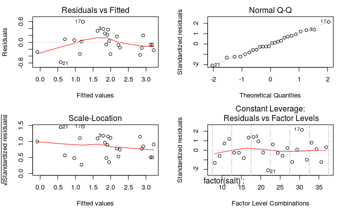

• Results of your statistical test, interpreting your test in 2-3 sentences that include the appropriate reporting of the statistics • An interpretation of any necessary post-hoc tests • An interpretation of diagnostic figures If you employ a model with a random effect use lmer() as the typical post-ANOVA diagnostics (e.g. plot(mod))) will not work with aov.

## Problem 2

Pangolins are scaly anteaters that inhabit the tropical forests of Asia and Africa and are hunted for their meat and their scales, which are made of hair. A researcher wants to evaluate the effect of diet on the thickness of pangolin scales, with the idea that thicker scales would better protect pangolins from predators. She rears pangolins and provides them with identical diets, but different doses (0.5, 1, 2 milligrams) of supplements (Vitamin B and Zinc). Download the ScaleThickness.csv file from Sakai and analyze the data to determine the potential effects of doses and supplements and whether there is an interaction between the two of them.

• Null and alternative hypotheses of your tests • Justification for your choice of ANOVA model • A description of how you checked the assumptions of your statistical test • Results of your statistical test, interpreting your test in 2-3 sentences that include the appropriate reporting of the statistics • An interpretation of any necessary post-hoc tests • An interpretation of diagnostic figures If you employ a model with a random effect use lmer() as the typical post-ANOVA diagnostics (e.g. plot(mod))) will not work with aov.